# 16.1. XML/XPath applications

Recall XPath expressions are ways to navigate to elements in XML documents. Very much like directory paths in Unix.

The XML document is treated as a tree of nodes with topmost element as root and different kinds of nodes: element, attribute, text, namespace, processing-instruction, comment, and document nodes.

The usual terms such as parent, child, sibling, ancestor, descendants are used to describe nodes.

There is a quick [primer here](http://zvon.org/comp/tests/r/test-xlab.html).

A rich set of functions is available to get at nodes including math, string manipulation etc. For details, [see this](http://www.w3schools.com/Xpath/xpath_functions.asp).

Typical XPath use involves a location specification that is then used in an expression. Location specification syntax: `axis::node[predicate]`

- `node` is a node tag, `*` is a wildcard, `text()` refers to a text node which have no names
- `axis` specifies the direction to look for a node such as: `child`, `ancestor`, `parent`, `descendant`, etc.
- `predicate` is a condition used to select node sets. This could be a condition that specifies a value for a particular attribute, for example.

An XPath expression returns either a node-set, a string, a Boolean, or a number.

We also said that in XML, you can define your own tags. This means that tag name collisions are inevitable. How to handle this? Enter Namespaces.

Namespaces help you to refer to specific contexts of the tags. Namespaces are implemented by attaching a prefix to each element and attribute. Each prefix is mapped to a URI (Uniform Resource Identifier) by an `xmlns:prefix` attribute. Avoids ambiguity.

The namespace is defined by the `xmlns` attribute in the start tag of an element. When a namespace is defined for an element, all child elements with the same prefix are associated with the same namespace. For this reason, it is often convenient to define the namespace in the root element of the document.

Not used by parser to look up information, although generally, one expects there to be some pointer to namespace info at the URI.

# 16.1.1 KEGG Pathways in Bioinformatics

In biology, there is a tremendous amount of pathway information coded in XML.

For example, consider the KEGG pathway for [Colorectal Cancer](http://www.genome.jp/kegg-bin/show_pathway?hsa05210).

There is help for reading this graph; the components of the pathways in KEGG are defined at [here](http://www.genome.jp/kegg/document/help_pathway.html).

- Rectangular box represents a gene product (a protein/RNA molecule)
- Small circle represents a compound
- Large oval represents a link to another pathway map
- Relationships for molecular interactions: `+p`,`-p`, `+g`, `+m` for phosphorlyation, dephosphorlyation, glycosylation and methylation
- Rectangular boxes are complexes

We will use the `xml2` package to process the Colorectal Cancer pathway from KEGG.

```r
library(xml2)
library(magrittr)
ccXML <- read_xml("hsa05210.xml")
```

Now we can pick off parts of the XML data. Say, the *first entry*.

```r
first <- "/pathway/entry[position()=1]"
result <- xml_find_all(ccXML, first)
result
```

```
## {xml_nodeset (1)}
## [1] <entry id="8" name="hsa:1630" type="gene" link="https://www.kegg.jp/dbget ...
```

The *last entry*.

```r
last <- "/pathway/entry[last()]"
result <- xml_find_all(ccXML, last)
result
```

```
## {xml_nodeset (1)}
## [1] <entry id="188" name="undefined" type="group">\n  <graphics fgcolor="#000 ...
```

*A gene entry.*

```r
geneEntry <- "/pathway/entry[@type = 'gene']"
result <- xml_find_all(ccXML, geneEntry)
```

*What is the name of the gene entry?*

```r
nameOfGeneEntry <- "/pathway/entry[@type = 'gene']/@name"
result <- xml_find_all(ccXML, nameOfGeneEntry) %>% xml_text
result
```

```
##  [1] "hsa:1630"
##  [2] "hsa:836"
##  [3] "hsa:7040 hsa:7042 hsa:7043"
##  [4] "hsa:5290 hsa:5291 hsa:5293 hsa:5295 hsa:5296 hsa:8503"
##  [5] "hsa:842"
##  [6] "hsa:26060"
##  [7] "hsa:836"
##  [8] "hsa:10297 hsa:324"
##  [9] "hsa:4087 hsa:4088"
## [10] "hsa:7046"
## [11] "hsa:4089"
## [12] "hsa:4292"
## [13] "hsa:4436"
## [14] "hsa:3845"
## [15] "hsa:369 hsa:5894 hsa:673"
```

[output cut: 57 more lines]

Let’s get just the unique names of all genes. Note that I need to account for multiple names for a single gene, separated by space.

```r
w <- stringr::str_split(result, pattern = " ")
geneNames <- unique(unlist(w))
geneNames
```

```
##  [1] "hsa:1630"  "hsa:836"   "hsa:7040"  "hsa:7042"  "hsa:7043"  "hsa:5290"
##  [7] "hsa:5291"  "hsa:5293"  "hsa:5295"  "hsa:5296"  "hsa:8503"  "hsa:842"
## [13] "hsa:26060" "hsa:10297" "hsa:324"   "hsa:4087"  "hsa:4088"  "hsa:7046"
## [19] "hsa:4089"  "hsa:4292"  "hsa:4436"  "hsa:3845"  "hsa:369"   "hsa:5894"
## [25] "hsa:673"   "hsa:5599"  "hsa:5601"  "hsa:5602"  "hsa:8312"  "hsa:8313"
## [31] "hsa:5900"  "hsa:387"   "hsa:5879"  "hsa:5880"  "hsa:5881"  "hsa:332"
## [37] "hsa:4609"  "hsa:595"   "hsa:5604"  "hsa:5605"  "hsa:5594"  "hsa:5595"
## [43] "hsa:3725"  "hsa:2353"  "hsa:54205" "hsa:596"   "hsa:7157"  "hsa:51176"
## [49] "hsa:6932"  "hsa:6934"  "hsa:83439" "hsa:2932"  "hsa:1499"  "hsa:10000"
## [55] "hsa:207"   "hsa:208"   "hsa:572"   "hsa:2956"  "hsa:581"   "hsa:4437"
## [61] "hsa:7048"  "hsa:1026"  "hsa:10912" "hsa:1647"  "hsa:4616"  "hsa:578"
## [67] "hsa:1643"  "hsa:51426" "hsa:5366"  "hsa:10018" "hsa:27113" "hsa:5898"
## [73] "hsa:5899"  "hsa:3265"  "hsa:4893"  "hsa:6198"  "hsa:6199"  "hsa:6654"
## [79] "hsa:6655"  "hsa:2885"  "hsa:2475"  "hsa:1956"  "hsa:1950"  "hsa:7039"
## [85] "hsa:2069"  "hsa:374"
```

# 16.1.2. Detecting relationships

How can we determine which gene phorphorylates another? For that we need to understand the structure of the XML. So you load it in your browser.

So this XML file has nodes named `entry` `graphics`, `relation` etc.

So perhaps, `relation` is what we are after.

Let’s work with the *KRAS* oncogene and its related neighbors.

We need to know more about the [KEGG Markup Language](http://www.kegg.jp/kegg/xml/docs/).

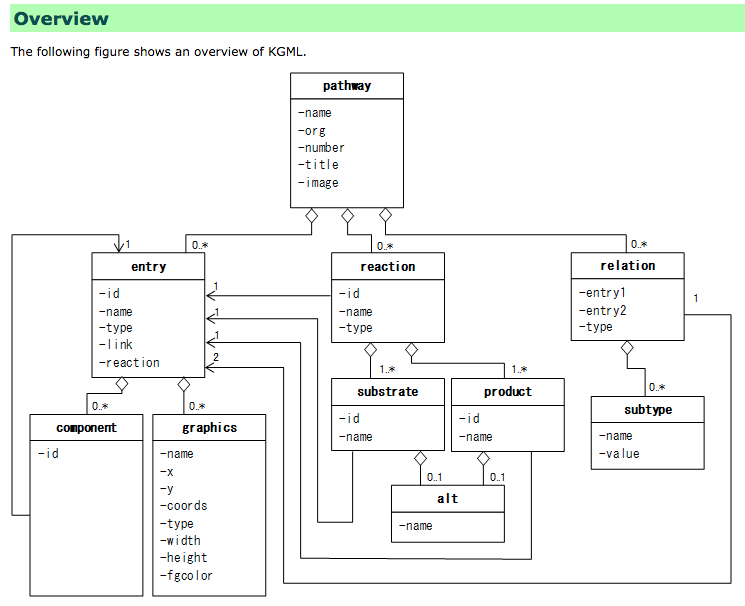

Obviously, each entry is uniquely identified by its identifier. So for the relation, we need all entries where `entry1` has the id of the *KRAS* gene, which we have to figure out.

The KRAS gene name in the KEGG scheme is [well-established](http://www.genome.jp/dbget-bin/www_bget?hsa:3845) to be `hsa:3845`.

First we find the KRAS gene id. We have to create the path expressions programmatically. Instead of using `paste` or `paste0` it is convenient to use `sprintf`.

```r
pathExp  <- sprintf("/pathway/relation[@entry1='%s']", "hsa:3845")
cat("Path Expression is", pathExp, "\n")
```

```
## Path Expression is /pathway/relation[@entry1='hsa:3845']
```

```r
ccXML %>%
    xml_find_all(xpath = "/pathway/entry[@name='hsa:3845']") %>%
    xml_attr(attr = "id") ->
    krasGeneId
cat("KRAS gene id in KEGG is", krasGeneId, "\n")
```

```
## KRAS gene id in KEGG is 21
```

Now for relations containing our gene. We first find all the neighbors of the KRAS gene.

```r
pathExp <- sprintf("/pathway/relation[@entry1='%s']", krasGeneId)
cat("path expression is for entry 1", pathExp, "\n")
```

```
## path expression is for entry 1 /pathway/relation[@entry1='21']
```

```r
ccXML %>%
    xml_find_all(xpath = pathExp) %>%
    xml_attr(attr = "entry2") ->
    krasNeighbors
```

This gets us all neighbours of KRAS who are listed in `entry2`, but might not be sufficient because there may be genes for which the `krasGeneId` might be the second entry! So we account for that.

```r
pathExp <- sprintf("/pathway/relation[@entry2='%s']", krasGeneId)
cat("path expression is for entry 2", pathExp, "\n")
```

```
## path expression is for entry 2 /pathway/relation[@entry2='21']
```

```r
ccXML %>%
    xml_find_all(xpath = pathExp) %>%
    xml_attr(attr = "entry1") %>%
    c(krasNeighbors) %>%  ## Combine with previous neigbours
    unique ->  ## Select unique values
    krasNeighbors
```

Let’s now look at the relationships.

```r
pathExp <- sprintf("/pathway/relation[@entry1='%s' and @entry2='%s']/subtype",
                   krasGeneId, krasNeighbors)
pathExp
```

```
## [1] "/pathway/relation[@entry1='21' and @entry2='11']/subtype"
## [2] "/pathway/relation[@entry1='21' and @entry2='22']/subtype"
## [3] "/pathway/relation[@entry1='21' and @entry2='26']/subtype"
```

If we try the first path expression for example, we get:

```r
xml_find_all(ccXML, pathExp[1])
```

```
## {xml_nodeset (1)}
## [1] <subtype name="activation" value="--&gt;"/>
```

But we’d like to do it all at once rather iterate for reasons of efficiency. We create a compound expression:

```r
cpathExp <- paste(pathExp, collapse = " | ")
cpathExp
```

```
## [1] "/pathway/relation[@entry1='21' and @entry2='11']/subtype | /pathway/relation[@entry1='21' and @entry2='22']/subtype | /pathway/relation[@entry1='21' and @entry2='26']/subtype"
```

This is now easy to apply to get the types of relationships.

```r
xml_find_all(ccXML, cpathExp)
```

```
## {xml_nodeset (3)}
## [1] <subtype name="activation" value="--&gt;"/>
## [2] <subtype name="activation" value="--&gt;"/>
## [3] <subtype name="activation" value="--&gt;"/>
```

So picking off the actual types of relationships is now trivial.

```r
pathExp <- sprintf("/pathway/relation[@entry1='%s' and @entry2='%s']/subtype",
                   krasGeneId, krasNeighbors)
cpathExp <- paste(pathExp, collapse = " | ")
rels <- xml_find_all(ccXML, cpathExp) %>%
    xml_attr(attr = "name")
print(rels)
```

```
## [1] "activation" "activation" "activation"
```

To detect all phosphorylation entries, let us examine something further. This requires looking at all nodes where the subtype has a name `phosphorylation`.

```r
pathExp <- "/pathway/relation/subtype[@name='phosphorylation']"
relations <- xml_find_all(ccXML, pathExp)
relations
```

```
## {xml_nodeset (10)}
##  [1] <subtype name="phosphorylation" value="+p"/>
##  [2] <subtype name="phosphorylation" value="+p"/>
##  [3] <subtype name="phosphorylation" value="+p"/>
##  [4] <subtype name="phosphorylation" value="+p"/>
##  [5] <subtype name="phosphorylation" value="+p"/>
##  [6] <subtype name="phosphorylation" value="+p"/>
##  [7] <subtype name="phosphorylation" value="+p"/>
##  [8] <subtype name="phosphorylation" value="+p"/>
##  [9] <subtype name="phosphorylation" value="+p"/>
## [10] <subtype name="phosphorylation" value="+p"/>
```

This is a problem, because we have now lost the parent!! But there is a way to get back to them using the xpath.

```r
pathExp <- "/pathway/relation/subtype[@name='phosphorylation']/.."
relations <- xml_find_all(ccXML, pathExp)
relations
```

```
## {xml_nodeset (10)}
##  [1] <relation entry1="45" entry2="42" type="PPrel">\n  <subtype name="phosph ...
##  [2] <relation entry1="45" entry2="46" type="PPrel">\n  <subtype name="phosph ...
##  [3] <relation entry1="45" entry2="47" type="PPrel">\n  <subtype name="phosph ...
##  [4] <relation entry1="22" entry2="32" type="PPrel">\n  <subtype name="phosph ...
##  [5] <relation entry1="32" entry2="33" type="PPrel">\n  <subtype name="phosph ...
##  [6] <relation entry1="33" entry2="34" type="PPrel">\n  <subtype name="phosph ...
##  [7] <relation entry1="33" entry2="35" type="PPrel">\n  <subtype name="phosph ...
##  [8] <relation entry1="33" entry2="36" type="PPrel">\n  <subtype name="phosph ...
##  [9] <relation entry1="162" entry2="161" type="PPrel">\n  <subtype name="acti ...
## [10] <relation entry1="161" entry2="160" type="PPrel">\n  <subtype name="acti ...
```

You can see how this data can be processed further. For example, all that is needed now is the names corresponding to the entries and we can construct the relationship back.

So you may ask, boy, what a lot of processing to get at stuff!

The key point is that the XML format provides a lot of flexibility for future extensions and so while the computing can be tedious at times, it is worth the effort.

# 16.1.3. Bioconductor example

I wish to point out that the important project Bioconductor relies more on the *recommended* package `XML` and so the approaches used there are different.

For example, here is how one would use that for mining protein-protein interactions.

```r
## Requires bioconductor. Install as:
## source("http://bioconductor.org/biocLite.R") followed by
## biocLite()
library(XML)
```

Protein-Protein interactions are encoded in `yeast.xml`. We parse and get the default namespaces.

```r
yeast <- xmlTreeParse("yeast.xml", useInternalNodes=TRUE)
nsY <- xmlNamespaceDefinitions(xmlRoot(yeast))
ns <- structure(sapply(nsY, function(x) x$uri), names = c("ns", "xsi"))

## Get interaction detection methods
idm <- getNodeSet(yeast, "//ns:interactionDetectionMethod//ns:fullName",
                  ns)
sapply(idm, xmlValue)
```

```
## [1] "two hybrid"
```

In this case, all the interaction methods are [two hybrid](https://en.wikipedia.org/wiki/Two-hybrid_screening) which is molecular biology technique for detecting protein-protein interactions.

We can also get the full name of the organism being studied.

```r
fullname <- getNodeSet(yeast, "//ns:hostOrganism//ns:fullName",
                       ns)
sapply(fullname, xmlValue)
```

```
## [1] "Saccharomyces cerevisiae"
```

Now the interactors:

```r
interactors <- getNodeSet(yeast, "//ns:interactorList//ns:interactor",
                          ns)
length(interactors)
```

```
## [1] 503
```

There are 503 protein-protein interactors.

Finally, the actual interactions.

```r
interactions <- getNodeSet(yeast, "//ns:interactionList/ns:interaction",
                           ns)
length(interactions)
```

```
## [1] 524
```

There are 524 protein-protein interactions.

# 16.1.4. Article Metadata Mining

The Library of Congress uses the [Metadata Object Description Schema](http://www.loc.gov/standards/mods/) for describing bibliographic elements. It can be used for a variety of purposes, particularly library applications.

Several open journals distribute their metadata in __MODS_ format. For example, the [Journal of Statistical Software](http://www.jstatsoft.org/) distributes a dump of all articles published.

Now suppose we wanted to mine this information. For example, consider finding all co-authors of author *Hornik* in the JSS. You can use Xpath expressions to get at this.

BTW, XPath has extensive capabilities that I am only briefly describing here for purposes of illustration.)

```r
doc <- read_xml("jstatsoft.xml")
xml_ns(doc)
```

```
## d1 <-> http://www.loc.gov/mods/v3
```

```r
ns <- xml_ns_rename(xml_ns(doc), d1 = "jss")
```

Get family name nodes and get the text value of the family names.

```r
xpath1 <- "//jss:namePart[@type='family']"
fnameNodes <- xml_find_all(doc, xpath1, ns = ns)
lastNames <- fnameNodes %>%
    xml_contents %>%
    xml_text
head(unique(sort(lastNames)))
```

```
## [1] "Achard"     "Adams"      "Admiraal"   "Ahn"        "Al-Subaihi"
## [6] "Alexander"
```

Recall that the `//` is a shortcut for anywhere in the tree. Read as: match the nodes no matter where in the tree they are.

If you wanted to focus on just the *first author* familyname:

```r
## Pick just the first author family name
xpath2 <- "/jss:modsCollection/jss:mods/jss:name[1]/jss:namePart[@type='family']"
cNodes <- xml_find_all(doc, xpath2, ns = ns)
fLastNames <- cNodes %>%
    xml_contents %>%
    xml_text
tail(unique(sort(fLastNames)))
```

```
## [1] "Yuan"    "Zamar"   "Zang"    "Zeileis" "Zhao"    "Zhou"
```

Same as above using position function

```r
xpath3 <- "/jss:modsCollection/jss:mods/jss:name[position() = 1]/jss:namePart[@type='family']"
cNodes <- xml_find_all(doc, xpath3, ns = ns)
fLastNames <- cNodes %>%
    xml_contents %>%
    xml_text
tail(unique(sort(fLastNames)))
```

```
## [1] "Yuan"    "Zamar"   "Zang"    "Zeileis" "Zhao"    "Zhou"
```

Ok, now we find all co-authors of Hornik in JSS excluding Hornik

```r
coAuthPath <- "//jss:namePart[@type='family' and string(.) = 'Hornik']/ancestor::jss:mods/jss:name/jss:namePart[@type='family' and not(./text()='Hornik')]/text()"
```

```r
cNodes <- xml_find_all(doc, coAuthPath, ns = ns)
cNodes %>%
    xml_text %>%
    unique
```

```
##  [1] "Zeileis"     "Leisch"      "Kleiber"     "Karatzoglou" "Smola"
##  [6] "Hahsler"     "Grün"        "Meyer"       "Buchta"      "Feinerer"
## [11] "Hothorn"     "Wiel"        "Leeuw"       "Mair"
```

# 16.1.5. Further Reading

The book by Deb Nolan and Duncan Temple Lang *XML and Web Technologies for Data Sciences with R* (Springer, freely available online for you) several further examples. However, it uses the `XML` package rather than `xml2`. I’ve done the translation for you here.

The vignettes in the `xml2` package are also worth reading.